# Help yourself: Assignment 1

Benjamin Moon & Christopher Davie https://github.com/ (PSYC 615 Lab)https://github.com/ChristopherADavie/Psyc_615_Base_R_Project_Folder

## Prerequisites

To access the datasets, help pages, and functions that we will use in this *help yourself*, load the following packages:

```r
here::i_am("labs/02_assumptions-ttests/help-yourself_assignment-1.Rmd")

library(here)
library(tidyverse)
library(ggpubr)
library(patchwork)
library(papaja)
library(psych)
library(broom)
library(car)
library(datawizard)
library(effectsize)
library(janitor)
```

If you run this code and get the error message “there is no package called ‘tidyverse’” (or a different package name), you will need to first install it, then run `library()` once again.

```r
install.packages("tidyverse")
library(tidyverse)
```

You only need to install a package once, but you need to reload it every time you start a new session.

If you need to be explicit about where a function (or dataset) comes from, you can use the special form `package::function()`. For example, `ggplot2::ggplot()` tells R explicitly that you are using the `ggplot()` function from the **ggplot2** package.

Telling R explicitly where a function comes from is called *namespacing*. The code below will always be explicit about where functions from loaded packages come from so that it is easier for you to help yourself when you want to learn more about a given function. However, you do not need to namespace functions in your code for assignments so long as you have the prerequisite packages loaded in your session.

## You’ve got this!

Getting good at programming will take some time, and the learning curve is often steep at first, but we know you can do it! Stick with it—you’ll be thankful you did in the future, even if you don’t think so now.

[figure not shown]

```r
knitr::include_graphics(here("images", "help-yourself-01_r-first-then.png"))
```

When you run into errors: try stuff out, search for help online, ask your peers, or find examples of code to copy (such as from these Help Yourselves). And check for typos. Always check for typos… If you’re still stuck after that then reach out to the TAs. We want you to succeed!

## Creating data sets

There are many ways to create data sets in R. If you want to create a data set where the code is laid out like a spreadsheet you can use the `tribble()` function from the **tibble** package. This is useful if you want to create a small data set with values you input manually. To get help using this function you can run `?tibble::tribble` in the R console.

```r
simpsons <- tibble::tribble(
  ~simpson, ~age,
  "homer",  36,
  "marge",  34,
  "bart",   10,
  "lisa",    8,
  "maggie",  1
)

simpsons
```

```
#> # A tibble: 5 × 2
#>   simpson   age
#>   <chr>   <dbl>
#> 1 homer      36
#> 2 marge      34
#> 3 bart       10
#> 4 lisa        8
#> 5 maggie      1
```

Alternatively, if you want to create a data set where each column is a vector of values you can use the `tibble()` function from the tibble package. To get help using this function you can run `?tibble::tibble` in the R console.

```r
# Here we recreate the data set from the code chunk above using the tibble
# function
simpson_name <- c("homer", "marge", "bart", "lisa", "maggie")
simpson_age  <- c(36, 34, 10, 8, 1)

simpsons <- tibble::tibble(simpson = simpson_name, age = simpson_age)

simpsons
```

```
#> # A tibble: 5 × 2
#>   simpson   age
#>   <chr>   <dbl>
#> 1 homer      36
#> 2 marge      34
#> 3 bart       10
#> 4 lisa        8
#> 5 maggie      1
```

### Simulating data

Creating data sets using the `tibble()` function is useful when you want to simulate data instead of entering it manually. R comes built in with a number of functions to simulate data with different distributions. You can see them all by running `?distributions` in the console. The most useful distribution to simulate in this course will be the normal distribution, which can be simulated with the `rnorm()` function. To get help using this function you can run `?rnorm` in the R console.

```r
set.seed(42)
normal_distribution <- rnorm(n = 10, mean = 30, sd = 5)

normal_distribution
```

```
#>  [1] 36.85479 27.17651 31.81564 33.16431 32.02134 29.46938 37.55761
#>  [8] 29.52670 40.09212 29.68643
```

All the simulation functions in R output vectors of values, which means you can use them with the `tibble()` function to create simulated data sets.

```r
# Here we construct a data set using the simulated normal distribution from the
# code chunk above, with an additional column containing the participant ID for
# each simulated value
simulated_dataset <- tibble::tibble(id = 1:10, value = normal_distribution)

simulated_dataset
```

```
#> # A tibble: 10 × 2
#>       id value
#>    <int> <dbl>
#>  1     1  36.9
#>  2     2  27.2
#>  3     3  31.8
#>  4     4  33.2
#>  5     5  32.0
#>  6     6  29.5
#>  7     7  37.6
#>  8     8  29.5
#>  9     9  40.1
#> 10    10  29.7
```

And a little extra trick, square rooting or squaring all the values of a normal distribution can be a quick and dirty way to skew the distribution.

## Wrangling data

It is often the case that the data you work with needs wrangling to make it fit for use. This could mean cleaning the data, but it could also mean adding new columns, removing rows, calculating new values, or transforming old values. The **dplyr** package has you covered for all of these actions and more. There are six main functions that will cover the majority of your data wrangling needs:

### Selecting

The `select()` function (`?dplyr::select`) allows you to select (and optionally rename) columns in a data frame.

```r
dplyr::select(.data = simpsons, age)
```

```
#> # A tibble: 5 × 1
#>     age
#>   <dbl>
#> 1    36
#> 2    34
#> 3    10
#> 4     8
#> 5     1
```

### Filtering

The `filter()` function (`?dplyr::filter`) is used to subset a data frame, retaining all rows that satisfy your conditions.

```r
dplyr::filter(.data = simpsons, simpson != "bart" & simpson != "lisa")
```

```
#> # A tibble: 3 × 2
#>   simpson   age
#>   <chr>   <dbl>
#> 1 homer      36
#> 2 marge      34
#> 3 maggie      1
```

### Mutating

The `mutate()` function (`?dplyr::mutate`) adds new columns and preserves existing ones. This function might be useful if you need to use the difference between two values for testing any statistical assumptions for a certain type of t-test (yes, this is an assignment question hint).

```r
dplyr::mutate(.data = simpsons, age_in_2021 = age + 34)
```

```
#> # A tibble: 5 × 3
#>   simpson   age age_in_2021
#>   <chr>   <dbl>       <dbl>
#> 1 homer      36          70
#> 2 marge      34          68
#> 3 bart       10          44
#> 4 lisa        8          42
#> 5 maggie      1          35
```

### Grouping and summarizing

The `group_by()` function (`?dplyr::group_by`) allows you to organize observations into groups and do data operations by group. The `ungroup()` function (`?dplyr::ungroup`) removes grouping.

The `summarize()` function (`?dplyr::summarize`) allows you to compute summary statistics on a data set either as a whole or by group by pairing it with the `group_by()` function.

```r
# First we need a variable to group by. We can create it using the mutate
# function.
simpsons <- dplyr::mutate(
  .data = simpsons,
  sex = c("male", "female", "male", "female", "female"),
  .before = age
)

# Then we group the data by sex
simpsons_grouped <- dplyr::group_by(.data = simpsons, sex)

# And finally we calculate some summary statistics using our grouping variable
simpsons_grouped <- dplyr::summarize(
  .data = simpsons_grouped,
  group_size = dplyr::n(),
  mean_age = mean(age),
  sd_age = sd(age)
)

simpsons_grouped
```

```
#> # A tibble: 2 × 4
#>   sex    group_size mean_age sd_age
#>   <chr>       <int>    <dbl>  <dbl>
#> 1 female          3     14.3   17.4
#> 2 male            2     23     18.4
```

The `summarize()` function can also be used independently to get summary statistics for the whole sample.

```r
dplyr::summarize(
  .data = simpsons,
  total_age = sum(age),
  median_age = median(age),
  mean_age = mean(age),
  sd_age = sd(age)
)
```

```
#> # A tibble: 1 × 4
#>   total_age median_age mean_age sd_age
#>       <dbl>      <dbl>    <dbl>  <dbl>
#> 1        89         10     17.8   16.1
```

### Arranging

The `arrange()` function (`?dplyr::arrange`) orders the rows of a data frame by the values of selected columns.

```r
dplyr::arrange(.data = simpsons, age)
```

```
#> # A tibble: 5 × 3
#>   simpson sex      age
#>   <chr>   <chr>  <dbl>
#> 1 maggie  female     1
#> 2 lisa    female     8
#> 3 bart    male      10
#> 4 marge   female    34
#> 5 homer   male      36
```

You can use the the `desc()` function (`?dplyr::desc`) to order the rows in descending order.

```r
dplyr::arrange(.data = simpsons, dplyr::desc(age))
```

```
#> # A tibble: 5 × 3
#>   simpson sex      age
#>   <chr>   <chr>  <dbl>
#> 1 homer   male      36
#> 2 marge   female    34
#> 3 bart    male      10
#> 4 lisa    female     8
#> 5 maggie  female     1
```

### Pivoting

```r
# This is the same `mutate()` code as above. Here we are saving it as an object
# so that we have meaningful data to pivot the data frame from. Note: After
# mutating, you may notice similarities between how the data frame looks here
# and in your assignment.
simpsons <- dplyr::mutate(.data = simpsons, age_in_2021 = age + 34)

simpsons_long <- tidyr::pivot_longer(
  simpsons,
  cols = c(age, age_in_2021),
  names_to = "context",
  values_to = "age"
)

simpsons_long
```

```
#> # A tibble: 10 × 4
#>    simpson sex    context       age
#>    <chr>   <chr>  <chr>       <dbl>
#>  1 homer   male   age            36
#>  2 homer   male   age_in_2021    70
#>  3 marge   female age            34
#>  4 marge   female age_in_2021    68
#>  5 bart    male   age            10
#>  6 bart    male   age_in_2021    44
#>  7 lisa    female age             8
#>  8 lisa    female age_in_2021    42
#>  9 maggie  female age             1
#> 10 maggie  female age_in_2021    35
```

The inverse transformation is the `pivot_wider()` function (`?tidyr::pivot_wider`), also from the **tidyr** package, which “widens” data, increasing the number of columns and decreasing the number of rows. Here we return the long version of our example data back to its previous state.

```r
tidyr::pivot_wider(simpsons_long, names_from = context, values_from = age)
```

```
#> # A tibble: 5 × 4
#>   simpson sex      age age_in_2021
#>   <chr>   <chr>  <dbl>       <dbl>
#> 1 homer   male      36          70
#> 2 marge   female    34          68
#> 3 bart    male      10          44
#> 4 lisa    female     8          42
#> 5 maggie  female     1          35
```

Pivoting data frames can be useful either as a method of tidying up a data frame, or for making certain data transformations easier to do (as you might need to do for the assignment when calculating adjusted means).

## File paths

Before you can read data you need to tell R where the data file is located. There are several ways to do this, some of them better than others.

The easiest—but also easiest to break—way is to write a character string with a path to the file, relative to your current working directory. You can check your current working directory by running `getwd()` in the console. If you do this, you should see that your current working directory is the `psyc-615-lab` directory

```r
string_path <- "data/help-yourself_01.csv"
string_path
```

```
#> [1] "data/help-yourself_01.csv"
```

A better way is to use the `file.path()` function (`?file.path`), which constructs the path to a file from components in a platform-independent way. This avoids file paths breaking between different operating systems, since Windows uses backslashes and OSX and Linux use forward slashes.

```r
function_path <- file.path("data", "help-yourself_01.csv")
function_path
```

```
#> [1] "data/help-yourself_01.csv"
```

The best way is to use the `here()` function (`?here::here`) from the **here** package. The `here()` function will always locate the files relative to your project root, in this case the `psyc-615-lab` directory. This is more consistent than locating files relative to your current working directory, and encourages the use of [project-oriented workflows](https://r4ds.had.co.nz/workflow-projects.html). You can use it as a drop-in replacement for `file.path()`.

```r
here_path <- here::here("data", "help-yourself_01.csv")
here_path
```

```
#> [1] "E:/Psyc_615_Base_R_Project_Folder-main/psyc-615-lab-main/data/help-yourself_01.csv"
```

You should read the here package vignettes to learn more about using `here()` in general (`vignette("here", package = "here")`) and in R Markdown documents such as this one (`vignette("rmarkdown", package = "here")`). After reading, if you scroll to line 15 of this document you will note that the `here::i_am()` function has already been set up for you. But you may need to set it up on your own at other points in this course.

## Reading data

There are a number of functions you can use to read different data files in R. For this course there are only two you need to worry about. To read CSV data files you can use the `read_csv()` (`?readr::read_csv`) function from the **readr** package.

```r
spiders <- readr::read_csv(here::here("data", "help-yourself_a1.csv"))
spiders
```

```
#> # A tibble: 24 × 3
#>     case group   anxiety
#>    <dbl> <chr>     <dbl>
#>  1     1 Picture      30
#>  2     2 Picture      35
#>  3     3 Picture      45
#>  4     4 Picture      40
#>  5     5 Picture      50
#>  6     6 Picture      35
#>  7     7 Picture      55
#>  8     8 Picture      25
#>  9     9 Picture      30
#> 10    10 Picture      45
#> # … with 14 more rows
```

To read SPSS `.sav` files you can use the `read_sav()` function (`?haven::read_sav`) from the **haven** package.

```r
spiders_sav <- haven::read_sav(here::here("data", "help-yourself_a1.sav"))
spiders_sav
```

```
#> # A tibble: 24 × 3
#>     case group   anxiety
#>    <dbl> <chr>     <dbl>
#>  1     1 Picture      30
#>  2     2 Picture      35
#>  3     3 Picture      45
#>  4     4 Picture      40
#>  5     5 Picture      50
#>  6     6 Picture      35
#>  7     7 Picture      55
#>  8     8 Picture      25
#>  9     9 Picture      30
#> 10    10 Picture      45
#> # … with 14 more rows
```

### Viewing data sets

There are a few ways to view data in R after you have imported it. If you just want to get a quick glimpse of the data you can use the `head()` or `tail()` functions (`?head`) to see the first or last 6 observations.

```r
tail(spiders)
```

```
#> # A tibble: 6 × 3
#>    case group       anxiety
#>   <dbl> <chr>         <dbl>
#> 1    19 Real Spider      50
#> 2    20 Real Spider      35
#> 3    21 Real Spider      30
#> 4    22 Real Spider      50
#> 5    23 Real Spider      60
#> 6    24 Real Spider      39
```

If you want to view the entire data frame you can either click on the object it belongs to in the Environment pane in RStudio, or you can use the `View()` function (`?View`).

```r
View(spiders)
```

Important note: By default the output of data sets and statistical tests is rounded when you output it in the R console. When the data is viewed in the RStudio viewer called by the `View()` function the output will not be rounded. In other words, output in the console is good for glancing at your data and test output, but the RStudio viewer contains the version of record. Keep this in mind when completing your assignments.

If you do want to see more digits printed in the console [you can change this](https://pillar.r-lib.org/reference/pillar_options.html) (and other printing methods).

## Visualizing data

R is a powerhouse for visualizing data, and makes it easy to create publication ready plots and tables.

### Creating plots

The plots you will make in this course will be simple, but if you enjoy data visualization then diving deeper into R’s plotting capabilities is a great investment (check out the *#tidytuesday* tag on Twitter if you want a taste). Data visualization in R is typically done with the **ggplot2** package, which is based on a grammar of graphics that allows you to assemble plots step by step to your exact specifications. A companion to ggplot2 is the **ggpubr** package, which simplifies the creation of plots common to scientific publications in APA style.

#### Histograms and box plots

Histograms are useful for visualizing the distribution of observations for a given variable. The `gghistogram()` function (`?ggpubr::gghistogram`) can be used to create a histogram. You can change the number and width of bins with the optional `bins` and `binwidth` arguments.

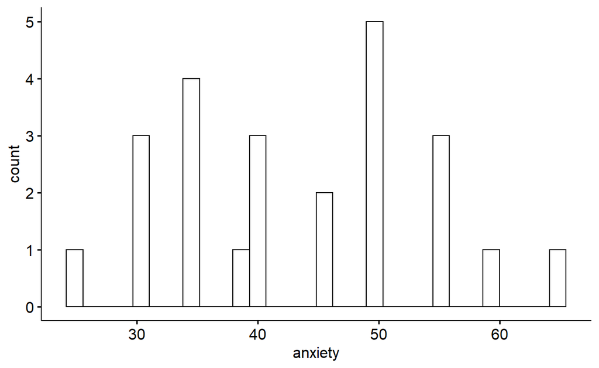

```r
ggpubr::gghistogram(data = spiders, x = "anxiety")
```

An alternative way to visualize the distribution of observations for a given variable is with boxplots. This can be useful if you want to emphasize different percentiles of the data. The `ggboxplot()` function (`?ggpubr::ggboxplot`) can be used to create a box plot.

```r
ggpubr::ggboxplot(data = spiders, y = "anxiety")
```

[output not shown]

#### Q-Q plots

Quantile-Quantile plots are a useful visual aid for assessing whether the distribution of observations for a given variable approximate a theoretical distribution, such as a the normal distribution. The `ggqqplot()` function (`?ggpubr::ggqqplot`) can be used to create a Q-Q plot.

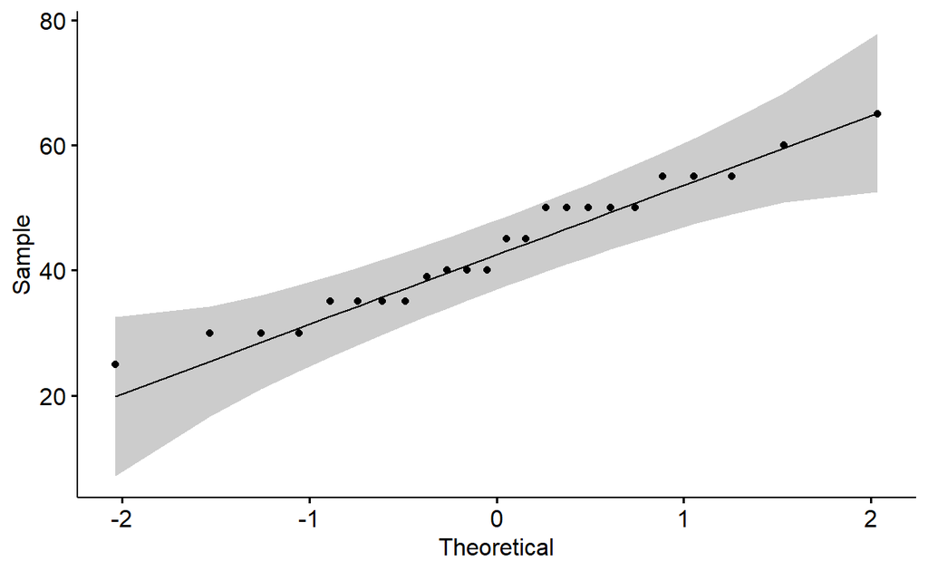

```r
ggpubr::ggqqplot(data = spiders, x = "anxiety")
```

#### Bar plots and line plots

Bar plots can be used to visualize group differences. The `ggbarplot()` function (`?ggpubr::ggbarplot`) can be used to create a bar plot. The optional `add` argument can be used to add descriptive statistics to the bars, such as means and confidence intervals.

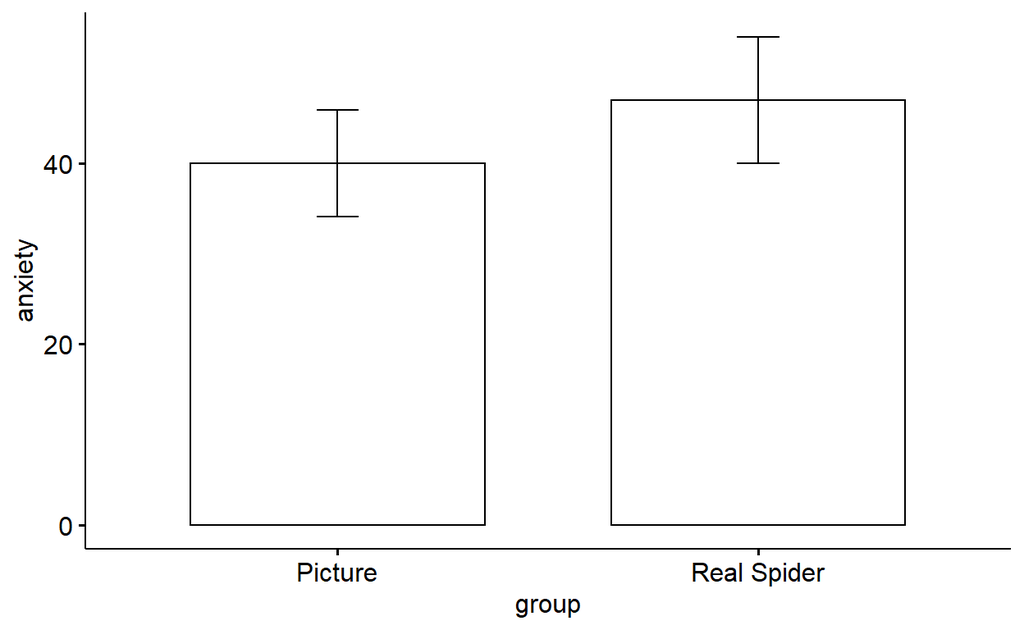

```r
ggpubr::ggbarplot(data = spiders, x = "group", y = "anxiety", add = "mean_ci")
```

An alternative to bar plots are line plots. These can be useful when visualizing changes in repeated measures data.

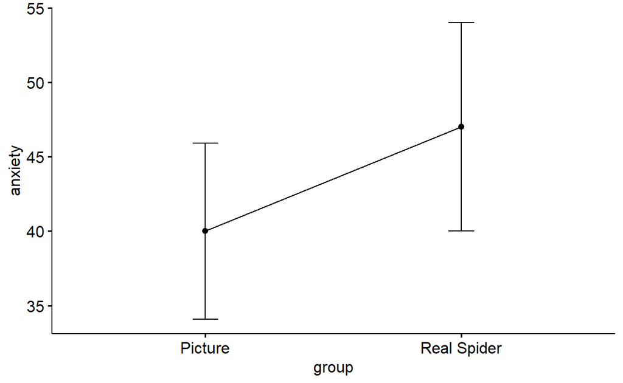

```r
ggpubr::ggline(data = spiders, x = "group", y = "anxiety", add = "mean_ci")
```

You can also plot bar and line plots with adjusted means using subject-centring (which might be useful on the assignment, hint hint). This requires some manual calculations prior to plotting.

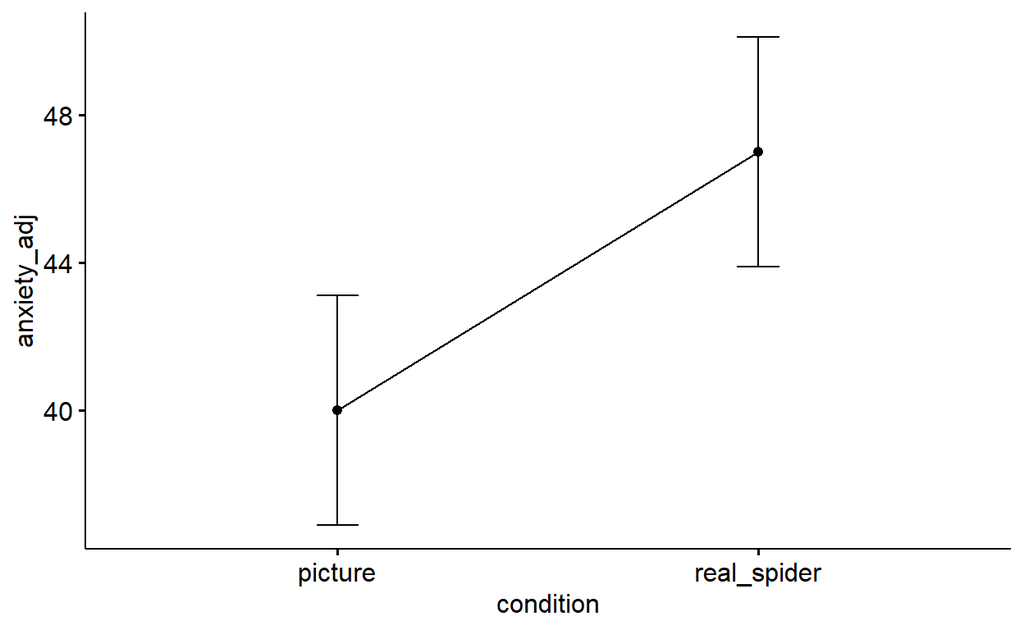

```r
# Here we will modify our example data to reflect a paired design before
# demonstrating the steps for calculating and plotting adjusted means
spiders_paired <- dplyr::mutate(spiders, case = rep(1:12, times = 2))
spiders_paired <- tidyr::pivot_wider(
  spiders_paired, names_from = group, values_from = anxiety
)
spiders_paired <- janitor::clean_names(spiders_paired)

# First pivot the data to long format if it isn't already
spiders_long <- tidyr::pivot_longer(
  spiders_paired,
  cols = c("picture", "real_spider"),
  names_to = "condition",
  values_to = "anxiety"
)

# Second calculate the grand mean for both contexts
anxiety_scores <- dplyr::pull(spiders_long, anxiety)
grand_mean <- mean(anxiety_scores)

# Third calculate each participant's mean score between the two contexts of the
# dependent variable, then an adjustment score by first subtracting the
# participant mean from the grand mean, then by adding the adjustment to
# participant scores in each context. You can accomplish this first by grouping
# by participant, then performing the calculations within the mutuate()
# function.
spiders_long <- dplyr::group_by(spiders_long, case)
spiders_long <- dplyr::mutate(
  spiders_long,
  mean_anxiety = mean(anxiety),
  adjustment = grand_mean - mean_anxiety,
  anxiety_adj = anxiety + adjustment
)

# Finally you can plot it using ggpubr
ggpubr::ggline(spiders_long, x = "condition", y = "anxiety_adj", add = "mean_ci")
```

### Composing plots

The plotting code above will serve your needs for most assignment questions in the course, but questions requiring APA style need a bit more formatting attention.

#### Labels

You may have noticed the axis labels in the plots above were all in lower case. Every plotting function in the ggpubr package has additional optional arguments—which you can see by going to the function’s help page—that can be used to change plot labels. Here is an example with the `ggbarplot()` function; note the additional `xlab` and `ylab` arguments.

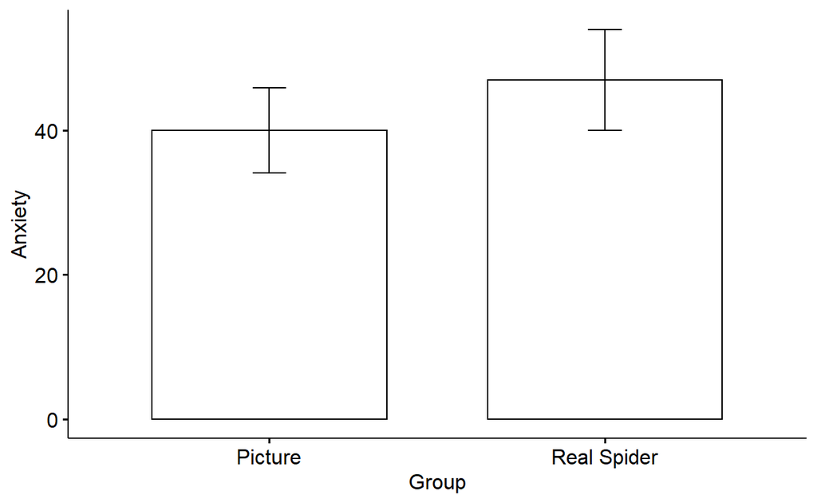

```r
ggpubr::ggbarplot(
  data = spiders,
  x = "group",
  y = "anxiety",
  add = "mean_ci",
  xlab = "Group",
  ylab = "Anxiety"
)
```

#### Moving the legend

APA requires legends to be located within the plotting area, but ggplot2 places legends outside the plotting area by default. If your plot has a legend you can move it with the `apa_legend()` function. This is a custom function included in the PSYC 615 Lab repository, you can make it available by using the `source()` function. Options for the `position` argument are: “topleft”, “topright”, “topmiddle”, “bottomleft”, “bottomright”, “bottommiddle”, or “none”.

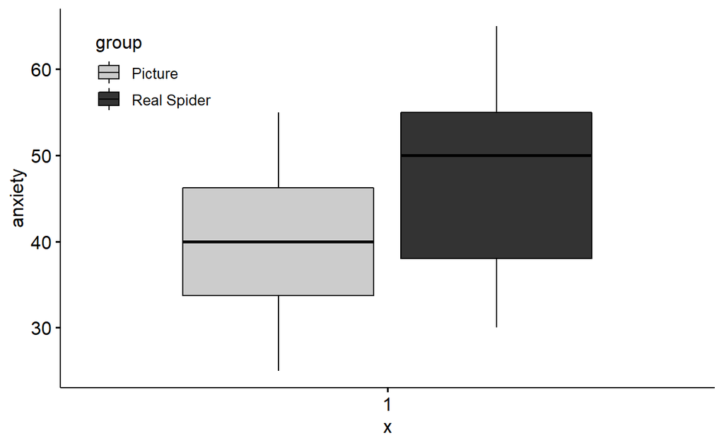

```r
# The source function runs R script files so their contents can be made
# available to use in R Markdown documents such as this one
source(here::here("R", "apa_legend.R"))

# The fill argument groups the data, resulting in a legend. The palette
# argument is used to change the fill colour of the boxplots.
grouped_boxplot <- ggpubr::ggboxplot(
  data = spiders,
  y = "anxiety",
  fill = "group",
  palette = "grey"
)

# Use ggplot2 syntax (the + sign) to move the legend
grouped_boxplot +
  apa_legend(position = "topleft")
```

#### Multiple plots as a single figure

The **patchwork** package makes it very easy to combine multiple plots into a single figure. Simply assign your plots to objects, then compose them using patchwork’s syntax. Note: the patchwork library needs to be loaded for this to work; in this document it was loaded in the prerequisites section.

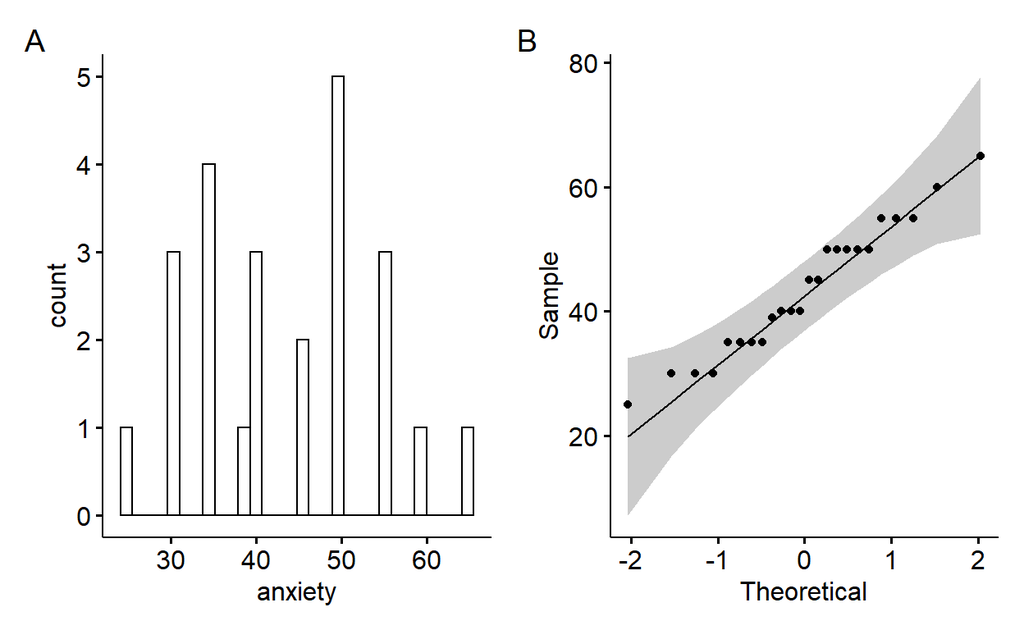

```r
# First create some plots
plot_a <- ggpubr::gghistogram(data = spiders, x = "anxiety")
plot_b <- ggpubr::ggqqplot(data = spiders, x = "anxiety")

# Then compose them together and add an annotation to distinguish them
plot_a + plot_b +
  patchwork::plot_annotation(tag_levels = "A")
```

#### Figure captions

APA style also requires figures to have captions. There are two ways to go about this in an R Markdown document. The first is to type the caption directly into the code chunk options of the chunk where your plot is output from, using the `fig.cap` chunk option (note: you need to look at the R Markdown file to see this, not the rendered document).

```r
ggpubr::ggboxplot(data = spiders, y = "anxiety")
```

[output not shown]

Figure 1: A short figure caption.

The second, and usually better, option is to place a reference to the caption in the code chunk options. You can see how this works below (note: you need to look at the R Markdown file to see this, not the rendered document).

```r
ggpubr::ggboxplot(data = spiders, y = "anxiety")
```

[output not shown]

Figure 2: When you have a long caption using the second option is better because it keeps your code chunk options short and clean.

### Tables

R also has great packages for making tables. Unfortunately you will not get to play around with these in this course. Partly because you will only ever make very simple tables in this course, and partly because R’s best table making packages do not support Microsoft Word documents at the moment.

The easiest way to output an APA style table in an R Markdown document is to use the `apa_table()` function (`?papaja::apa_table`) from the **papaja** package. This function takes a data frame and APA styles it when you knit your document, with an optional caption using the `caption` argument.

```r
# If you run this code in the console the output will look like gibberish. You
# need to knit the document as a PDF or Word file to see the proper result.
apa_tab <- papaja::apa_table(simpsons, caption = "Table showing Simpsons ages")
```

However, you should note that the `apa_table()` function will not do all the APA styling work for you. Things such as capitalization, number of digits printed, and so forth must be either: (1) Handled beforehand in the data frame given to the `apa_table()` function; or (2) handled afterwords manually in Microsoft Word.

## Including images

If you need to include any images in your R Markdown document you can use the `knitr::include_graphics()` function(`?knitr::include_graphics`) from the **knitr** package. Note that you actually need to use the `knitr::` namespacing for this one. Images can also be given captions using the same method as with plots.

[figure not shown]

```r
knitr::include_graphics(here::here("images", "help-yourself-01_outlier.png"))
```

## Descriptive statistics

### Mean and standard deviation

The `mean()` function (`?mean`) takes a vector of numbers as input and returns the mean as output.

```r
zero_to_one_hundred <- 0:100

mean(zero_to_one_hundred)
```

```
#> [1] 50
```

The `sd()` function (`?sd`) works the same way as the `mean()` function, but returns the standard deviation as output.

```r
some_numbers <- c(1, 15, 98, 45, 37, 56)

sd(some_numbers)
```

```
#> [1] 33.98823
```

### Skewness and kurtosis

The `skewness()` and `kurtosis()` functions (`?datawizard::skewness`) from the **datawizard** package can be used to calculate skewness and kurtosis. There are different algorithms for calculating skewness and kurtosis, these can be selected using the optional `type` argument (`type = 2` matches SPSS and SAS).

```r
datawizard::skewness(some_numbers)
```

```
#> Skewness |    SE
#> ----------------
#>    0.685 | 0.617
```

```r
datawizard::kurtosis(some_numbers)
```

```
#> Kurtosis |    SE
#> ----------------
#>    0.690 | 0.597
```

### Calculate all descriptive statistics with a single function

You can also use the `describe()` function (`?psych::describe`) from the **psych** package to calculate all your descriptive statistics at once. The optional `type` argument selects which algorithm to calculate skewness and kurtosis with (`type = 2` matches SPSS and SAS). Note that the `describe()` function will calculate descriptive statistics for all columns in a data frame, even if that would not make sense for all columns. You can wrangle your data frame beforehand with the `select()` function from the dplyr package if you only want to see output for the relevant columns.

```r
psych::describe(spiders, type = 2)
```

```
#>         vars  n mean    sd median trimmed   mad min max range skew
#> case       1 24 12.5  7.07   12.5    12.5  8.90   1  24    23 0.00
#> group*     2 24  1.5  0.51    1.5     1.5  0.74   1   2     1 0.00
#> anxiety    3 24 43.5 10.60   42.5    43.2 11.12  25  65    40 0.16
#>         kurtosis   se
#> case       -1.20 1.44
#> group*     -2.19 0.10
#> anxiety    -0.80 2.16
```

You can use the `describeBy()` function (`?psych::describeBy`) if you want to calculate all descriptive statistics by a grouping variable.

```r
psych::describeBy(spiders, group = "group", type = 2)
```

```
#>
#>  Descriptive statistics by group
#> group: Picture
#>         vars  n mean   sd median trimmed   mad min max range skew
#> case       1 12  6.5 3.61    6.5     6.5  4.45   1  12    11    0
#> group*     2 12  1.0 0.00    1.0     1.0  0.00   1   1     0  NaN
#> anxiety    3 12 40.0 9.29   40.0    40.0 11.12  25  55    30    0
#>         kurtosis   se
#> case        -1.2 1.04
#> group*       NaN 0.00
#> anxiety     -1.0 2.68
#> ----------------------------------------------------
#> group: Real Spider
#>         vars  n mean    sd median trimmed   mad min max range  skew
#> case       1 12 18.5  3.61   18.5    18.5  4.45  13  24    11  0.00
#> group*     2 12  1.0  0.00    1.0     1.0  0.00   1   1     0   NaN
#> anxiety    3 12 47.0 11.03   50.0    46.9 14.83  30  65    35 -0.01
#>         kurtosis   se
#> case       -1.20 1.04
#> group*       NaN 0.00
#> anxiety    -1.12 3.18
```

## Statistical assumptions

### Shapiro-Wilk test

```r
shapiro.test(some_numbers)
```

```
#>
#>  Shapiro-Wilk normality test
#>
#> data:  some_numbers
#> W = 0.96307, p-value = 0.8431
```

The `shapiro.test()` function takes a numeric vector of values as its input, so you need to specify which column you would like to run the test for if your data is in a data frame. You can do this using either the `pull()` function (`?dplyr::pull`) from the dplyr package, or one of R’s extract operators (`?Extract`).

```r
# The pull function lets you use a familiar syntax to other functions
anxiety_values_pull <- dplyr::pull(.data = spiders, var = anxiety)

# R's extract operators have a unique syntax that is more concise. These are
# all interchangeable so you may see different ones used by different people.
anxiety_values_dollar <- spiders$anxiety
anxiety_values_sqbr   <- spiders[["anxiety"]]

# If you put any of the anxiety_values_ vectors in the shapiro.test() function
# below you will see that you get the same result for each
shapiro.test(anxiety_values_pull)
```

```
#>
#>  Shapiro-Wilk normality test
#>
#> data:  anxiety_values_pull
#> W = 0.96282, p-value = 0.4977
```

If you want easy programmatic access to the output of the `shapiro.test()` function you can use the `tidy()` function (`?broom::tidy`) from the **broom** package. This will tidy the output into a data frame, which you can then do other functions on. For instance, you might want to put the results in an APA table using the `apa_table()` function mentioned previously, or you might want to round the test statistic to two digits using the `round()` function. See the function help (`?broom::tidy.htest`) for details about what the value in each column means.

```r
shapiro_test_anxiety <- shapiro.test(anxiety_values_pull)

broom::tidy(shapiro_test_anxiety)
```

```
#> # A tibble: 1 × 3
#>   statistic p.value method
#>       <dbl>   <dbl> <chr>
#> 1     0.963   0.498 Shapiro-Wilk normality test
```

And if you want to run the test by group we made a custom `shapiro_test()` function you can use. This is a custom function included in the PSYC 615 Lab repository, you can make it available by using the `source()` function.

```r
# The source the `shapiro_test()` function
source(here::here("R", "shapiro_test.R"))

# Note: The group argument is optional, so you can also use this function
# as a replacement for the `shapiro.test()` function
shapiro_test(spiders, var = anxiety, group = group)
```

```
#> # A tibble: 2 × 4
#>   group       statistic p.value method
#>   <chr>           <dbl>   <dbl> <chr>
#> 1 Picture         0.965   0.852 Shapiro-Wilk normality test
#> 2 Real Spider     0.949   0.621 Shapiro-Wilk normality test
```

### Levene’s test

Levene’s test of homogeneity of variance can be used to test whether the variance of a variable is equal across groups. You can use the `leveneTest()` function (`?car::leveneTest`) from the **car** package to calculate the Levene’s test statistic ($F$) and the p-value for the test. There are two ways to use this function, each giving the same result but with different syntax. Pick whichever you like.

The first option requires you to extract the variable and group columns you want to use to calculate Levene’s test from your data frame.

```r
# Here we extract the numeric vector for anxiety and the character vector for
# group from the `spiders` data frame using the `$` extractor mentioned in the
# previous section.
car::leveneTest(y = spiders$anxiety, group = spiders$group, center = mean)
```

```
#> Levene's Test for Homogeneity of Variance (center = mean)
#>       Df F value Pr(>F)
#> group  1  0.7816 0.3862
#>       22
```

The second option uses R’s formula syntax (`?formula`), placing the variable column to the left of the tilde and the group column to the right, then specifying the data frame those columns belong to using the `data` argument.

```r
car::leveneTest(anxiety ~ group, center = mean, data = spiders)
```

```
#> Levene's Test for Homogeneity of Variance (center = mean)
#>       Df F value Pr(>F)
#> group  1  0.7816 0.3862
#>       22
```

If you want easy programmatic access to the output of the `leveneTest()` function you can use the `tidy()` function (`?broom::tidy.leveneTest`) from the **broom** package here too (the `tidy()` function works with most statistical models in R). See the function help (`?broom::tidy.htest`) for details about what the value in each column means.

```r
# Here we split this code up into multiple lines in order to follow the
# tidyverse style guide. The guide states that when a line of code exceeds 80
# characters it should be broken into multiple lines for readability.
levenes_test_anxiety <- car::leveneTest(
  anxiety ~ group,
  center = mean,
  data = spiders
)

broom::tidy(levenes_test_anxiety)
```

```
#> # A tibble: 1 × 4
#>   statistic p.value    df df.residual
#>       <dbl>   <dbl> <int>       <int>
#> 1     0.782   0.386     1          22
```

## t-tests

All the different types of t-tests in R use the same `t.test()` function (`?t.test`), but each uses different optional arguments to determine which t-test is run. There are two ways to use this function for a given type of t-test, each way giving the same result but with different syntax (like with the `leveneTest()` function above).

### Single Sample t-test

The single sample t-test tests whether a group of values significantly differ from a specified value. It uses the optional `mu` argument to indicate the true value of the mean. You can either use this function with extracted values:

```r
t.test(spiders$anxiety, mu = 20)
```

```
#>
#>  One Sample t-test
#>
#> data:  spiders$anxiety
#> t = 10.866, df = 23, p-value = 1.56e-10
#> alternative hypothesis: true mean is not equal to 20
#> 95 percent confidence interval:
#>  39.02599 47.97401
#> sample estimates:
#> mean of x
#>      43.5
```

Or with the formula syntax:

```r
t.test(anxiety ~ 1, mu = 20, data = spiders)
```

```
#>
#>  One Sample t-test
#>
#> data:  anxiety
#> t = 10.866, df = 23, p-value = 1.56e-10
#> alternative hypothesis: true mean is not equal to 20
#> 95 percent confidence interval:
#>  39.02599 47.97401
#> sample estimates:
#> mean of x
#>      43.5
```

### Independent t-test

The independent t-test tests whether the values in two distinct unrelated groups significantly differ from each other.

You can either use this function with extracted values from each group:

```r
# First you have to create separate data frames for each group. The filter
# function is the easiest way to do this.
spider_pic_group <- dplyr::filter(.data = spiders, group == "Picture")
spider_real_group <- dplyr::filter(.data = spiders, group == "Real Spider")

# Afterwords you can extract the same variable from each data frame to compare
# the two groups.
t.test(x = spider_pic_group$anxiety, y = spider_real_group$anxiety)
```

```
#>
#>  Welch Two Sample t-test
#>
#> data:  spider_pic_group$anxiety and spider_real_group$anxiety
#> t = -1.6813, df = 21.385, p-value = 0.1072
#> alternative hypothesis: true difference in means is not equal to 0
#> 95 percent confidence interval:
#>  -15.648641   1.648641
#> sample estimates:
#> mean of x mean of y
#>        40        47
```

Or with the formula syntax, where the dependent variable goes to the left of the tilde and the independent variable goes to the right. (As you may have noticed by now R’s formula syntax tends to result in cleaner, shorter code).

```r
t.test(anxiety ~ group, data = spiders)
```

```
#>
#>  Welch Two Sample t-test
#>
#> data:  anxiety by group
#> t = -1.6813, df = 21.385, p-value = 0.1072
#> alternative hypothesis: true difference in means between group Picture and group Real Spider is not equal to 0
#> 95 percent confidence interval:
#>  -15.648641   1.648641
#> sample estimates:
#>     mean in group Picture mean in group Real Spider
#>                        40                        47
```

### Dependent t-test

The dependent t-test tests whether the values within the same group (or a matched group) significantly differ across two contexts. It uses the optional `paired` argument to indicate that the values in your data are dependent on each other.

You can either use this function with extracted values from each group:

```r
# Here we can pretend participants first had their anxiety measured while
# looking at pictures of spiders, then afterwords had their anxiety measured
# while looking at real spiders.
t.test(
  x = spider_pic_group$anxiety,
  y = spider_real_group$anxiety,
  paired = TRUE
)
```

```
#>
#>  Paired t-test
#>
#> data:  spider_pic_group$anxiety and spider_real_group$anxiety
#> t = -2.4725, df = 11, p-value = 0.03098
#> alternative hypothesis: true mean difference is not equal to 0
#> 95 percent confidence interval:
#>  -13.2312185  -0.7687815
#> sample estimates:
#> mean difference
#>              -7
```

Or with the formula syntax, where the dependent variable goes to the left of the tilde and the independent variable goes to the right.

```r
t.test(anxiety ~ group, paired = TRUE, data = spiders)
```

```
#>
#>  Paired t-test
#>
#> data:  anxiety by group
#> t = -2.4725, df = 11, p-value = 0.03098
#> alternative hypothesis: true mean difference is not equal to 0
#> 95 percent confidence interval:
#>  -13.2312185  -0.7687815
#> sample estimates:
#> mean difference
#>              -7
```

### Tidy t-tests

The output of the `t.test()` function can be tidied with the `tidy()` function from the broom package. See the function help (`?broom::tidy.htest`) for details about what the value in each column means.

```r
# This example uses the independent t-test code from the chunks above
ttest_fit_anxiety <- t.test(anxiety ~ group, data = spiders)

broom::tidy(ttest_fit_anxiety)
```

```
#> # A tibble: 1 × 10
#>   estimate estimate1 estimate2 stati…¹ p.value param…² conf.…³ conf.…⁴
#>      <dbl>     <dbl>     <dbl>   <dbl>   <dbl>   <dbl>   <dbl>   <dbl>
#> 1       -7        40        47   -1.68   0.107    21.4   -15.6    1.65
#> # … with 2 more variables: method <chr>, alternative <chr>, and
#> #   abbreviated variable names ¹statistic, ²parameter, ³conf.low,
#> #   ⁴conf.high
```

### Cohen’s d

The `cohens_d()` function (`?effectsize::cohens_d`) from the **effectsize** package can be used to calculate Cohen’s d ($d$).

Just like with the `t-test()` function, you can either use this function with extracted values from each group.

```r
# This example calculates Cohen's d for the independent t-test in the code
# chunks above
effectsize::cohens_d(
  x = spider_pic_group$anxiety,
  y = spider_real_group$anxiety
)
```

```
#> Cohen's d |        95% CI
#> -------------------------
#> -0.69     | [-1.50, 0.15]
#>
#> - Estimated using pooled SD.
```

Or with the formula syntax, where the dependent variable goes to the left of the tilde and the independent variable goes to the right.

```r
# This example calculates Cohen's d for the independent t-test in the code
# chunks above
effectsize::cohens_d(anxiety ~ group, data = spiders)
```

```
#> Cohen's d |        95% CI
#> -------------------------
#> -0.69     | [-1.50, 0.15]
#>
#> - Estimated using pooled SD.
```

The simplest approach is to choose whichever syntax you used with the t.test() function, since you can then drop the arguments you used there directly into `cohens_d()` without any changes.

## Learning more

### From the R for Data Science book

- R basics https://r4ds.had.co.nz/workflow-basics.html
- An introduction to RStudio projects https://r4ds.had.co.nz/workflow-projects.html
- An introduction to R Markdown https://r4ds.had.co.nz/r-markdown.html
- More details on tibbles and data wrangling in R https://r4ds.had.co.nz/wrangle-intro.html
- Details on pipes (`%>%`) in R (we did not cover pipes in this Help Yourself but you may want to use them for the assignment, and we will use them in future code examples) https://r4ds.had.co.nz/pipes.html

### Styling and formatting your R code for readability

- The tidyverse style guide https://style.tidyverse.org

### Statistics

- Learn statistics and programming with the free Stats of DOOM course, videos, slides, and course materials available at https://statisticsofdoom.com

### Assumptions

- Dealing with outliers https://www.rips-irsp.com/articles/10.5334/irsp.289/